# 30 Day Map Challenge - Ecoinformática AEET

Sonia Illanas

2025-10-15

## 30 Day Map Challenge - 15_Fire

### Day callenge description

The aim of this work was to present the distribution of fires over the last decade in Spain, at the smallest administrative level (municipalities).

To do so, you may need:

1. To download a fire polygon vector layer. I used the the EFFIS (European Forest Fire Information System) which updates the status of ongoing fires across Europe **daily**. In their own words: *“it provides near real-time and historical information on forest fires.”* This is open data (available, public and free) that can be accessed and downloaded from [here](https://forest-fire.emergency.copernicus.eu/applications/data-and-services). However, feel free to use any other repository you prefer.
2. To download a polygon vector layer. Since the spatial resolution used in this example are municipalities in Spain, I downloaded the data from [here](https://centrodedescargas.cnig.es/CentroDescargas/limites-municipales-provinciales-autonomicos). Be aware that any other spatial resolutions, such as grid, provinces, counties in other countries, national boundaries, could be also used depending on your needs!

### Load the data

First at all: load the layers you are interested.

```r
fires<-st_read("./data/effis_layer/modis.ba.polyES.shp", quiet=TRUE) %>% st_transform(3035)
firesES<-fires %>% filter(COUNTRY=="ES")  #used country code to select the country you're interested

muni<-st_read("./data/lineas_limite/recintos_municipales_inspire_peninbal_etrs89.shp", quiet=TRUE) %>% st_transform(3035)
muni$area_ha<-st_area(muni)/10000 # calculate municipalities area in ha
attributes(muni$area_ha)<-NULL  # remove ha attribute from the col
```

### Data preparation

Intersect the fire layer with the spatial polygon layer that you’re interested, in our case Spanish municipalities.

```r
# it could take some time to do it depending on your computer, be patient!
intersections <- st_intersection(muni, firesES)
intersections<-intersections %>% mutate(area_ha.fire=st_area(geometry)/10000)
attributes(intersections$area_ha.fire)<-NULL
```

Group fires per municipality and sum number of fires and surface burnt in each one.

```r
fires<-intersections %>%
          as_tibble() %>%
          mutate(count=1) %>%
          group_by(NATCODE, NAMEUNIT) %>%
          summarize(area_ha.fire=sum(area_ha.fire),
                    n.fires=sum(count))
```

Join the information of fires from the intersection with the municipalities by their ID codes.

```r
# ID code = NATCODE & NAMEUNIT
fires2<-muni %>% left_join(fires, by=c("NATCODE", "NAMEUNIT"))

fires2<- fires2 %>%
            rename(area_ha.tm=area_ha) %>%
            mutate(n.fires=replace_na(n.fires, 0),
                   area_ha.fire=replace_na(area_ha.fire, 0),
                   perc.burnt=area_ha.fire/area_ha.tm*100)
```

Save results in a geopackge (.gpkg) or any other vector layer format.

```r
# st_write(fires2, "15Fires.gpkg", layer="FiresTM")
```

### Plot

Let’s plot the fire map!

First I will create a map showing the number of fires produced in each municipality over 2016-2025.

```r
pal_inferno_black <- c("black", inferno(10)[2:10])
prov<-st_read("./data/lineas_limite/recintos_provinciales_inspire_peninbal_etrs89.shp", quiet=TRUE) %>% st_transform(3035)

tmap_mode("plot")
p1<-tm_shape(fires2) +
      tm_fill("n.fires",
              fill.scale =
                tm_scale_intervals(breaks = c(0, 1, 10, 50, 100, 150, 200, 250, 300),
                                   values  = pal_inferno_black),
              fill_alpha = 0.9,
              fill.legend = tm_legend(title = "Number of fires \n per municipality \n",
                                      frame = FALSE)) +
      tm_legend(frame = FALSE,
                position = c("right", "bottom"),
                height = 11.3,
                title.size = 0.8,
                title.color = "white",
                text.size = 0.6,
                text.color = "white",
                bg.color = "black",
                item.space = 1.2)+
      # tm_title(text = "                                  Fires over the last decade in Spain (2016–2025)",
      #          color="white",
      #          fontface = "bold",
      #          position = c("center", "top"),
      #          size = 1.1)+
      tm_layout(bg.color = "black",
                frame = FALSE,
                legend.frame = FALSE,
                outer.bg.color = "black"
                ) +
      # tm_credits("Data from Copernicus",
      #            position = c("center", "bottom"),
      #            color = "white")+
  tm_shape(prov)+
    tm_borders(col="white")
# p1
```

Second, I will create a map showing the area burned in each municipality relative to its total surface (%) for the same period.

```r
p2<-tm_shape(fires2) +
      tm_fill("perc.burnt",
              fill.scale =
                tm_scale_intervals(breaks = c(0, 1, 3, 5, 10, 20, 40, 80, 120),
                                   values = pal_inferno_black),
                fill_alpha = 0.9,
                fill.legend = tm_legend(title = "Burnt area of each \n municipality (%) \n",
                                        frame = FALSE)) +
      tm_legend(frame = FALSE,
                position = c("right", "bottom"),
                height = 11.3,
                title.size = 0.8,
                title.color = "white",
                text.size = 0.6,
                text.color = "white",
                bg.color = "black",
                item.space = 1.2)+
      # tm_title(text = "                                  Fires over the last decade in Spain (2016–2025)",
      #          color="white",
      #          fontface = "bold",
      #          position = c("center", "top"),
      #          size = 1.1)+
      tm_layout(bg.color = "black",
                frame = FALSE,
                legend.frame = FALSE,
                outer.bg.color = "black"
                ) +
      # tm_credits("Data from Copernicus",
      #            position = c("center", "bottom"),
      #            color = "white")+
  tm_shape(prov)+
      tm_borders(col="white")

# p2
```

Finally, I will combine both maps to produce a single map.

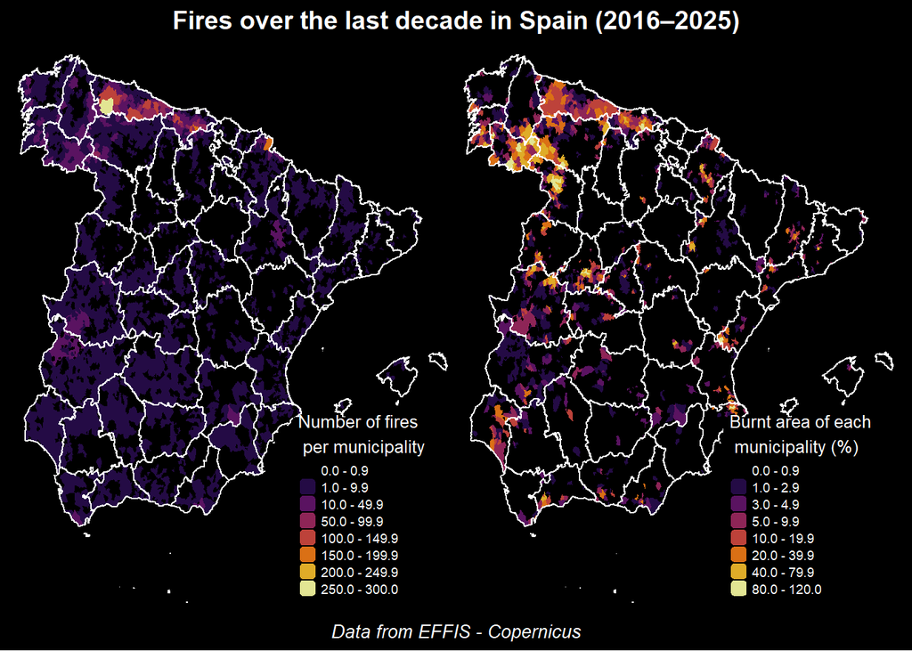

```r
library(grid)
library(gridExtra)
g1 <- tmap_grob(p1)
g2 <- tmap_grob(p2)

library(ggplotify)
ggobj1 <- as.ggplot(g1)
ggobj2 <- as.ggplot(g2)

library(patchwork)
combined<-(ggobj1 | ggobj2) +
      plot_annotation(title = "Fires over the last decade in Spain (2016–2025)",
                      caption = "Data from EFFIS - Copernicus",
                      theme = theme(plot.title =
                                    element_text(colour = "white",
                                                 size=14,
                                                 face = "bold",
                                                 hjust=0.5),
                                    plot.caption =
                                    element_text(colour = "white",
                                                 size=10,
                                                 face = "italic",
                                                 hjust=0.5),
                                    plot.background =
                                    element_rect(fill = "black",
                                                 color = NA)))
combined
```

Save the map as an image:

```r
# save results in a png/svg/image format
# ggsave(filename = "15_fires.png", # filename of the plot
#        plot = combined,           # plot to save
#        width = 30, height = 15,   # dimensions
#        units = "cm",              # dimension units
#        dpi = 300)
```

Happy coding! :)